# Kto udowodnił to twierdzenie?

Matematyka w epoce sztucznej inteligencji

Tomasz Rodak

Uniwersytet Łódzki, Wydział Matematyki i Informatyki

23 października 2026

[figure not shown]

ENIAC, 1946: pierwszy elektroniczny komputer ogólnego przeznaczenia

8 września 2026

jeden problem milenijny  
ok. 10 000 agentów AI, 88 godzin  
166 stron dowodu

6 października 2026

ok. 4000 otwartych problemów  
722 prace  
udostępnione naraz

Co wydarzyło się pomiędzy?

## Kto udowodnił to twierdzenie?

rachunek**1946***ENIAC liczy*

sprawdzanie  
przypadków

szukanie

dowód**2026**agenci AI proponują  
dowody i kontrprzykłady  
w otwartych problemach

pytania  
teoria  
zastosowania

Co po drodze człowiek oddał maszynie?

## Demo

Znajdź **odwracalne odwzorowanie wielomianowe** płaszczyzny, które przestawia te punkty tak, jak pokazują strzałki — o możliwie niskim stopniu.

znana konstrukcja: stopień $(m-1)^2 = 16$ · czy da się niżej?

Agenci AI zaczynają **teraz**.  
Nikt im nie pomaga.  
Wyniki na końcu wykładu.

# Delegowanie jest stare

rachunek sprawdzanie przypadków szukanie dowód pytania · teoria · zastosowania

## Platon, *Fajdros*

[figure not shown]

*Fajdros* na papirusie z Oksyrynchos (Egipt), II–III w. n.e.

Król Thamus o piśmie: ludzie przestaną ćwiczyć pamięć, bo zaufają zapisanym znakom.

Wiemy o tym tylko dzięki pismu.

## 347 · 28 na trzy sposoby

w pamięci

człowiek: wszystko

pisemnie

[figure not shown]

człowiek: kolejne kroki  
papier: pamięć

kalkulator

[figure not shown]

człowiek: wpisuje liczby  
maszyna: cały rachunek

## Przed elektroniką

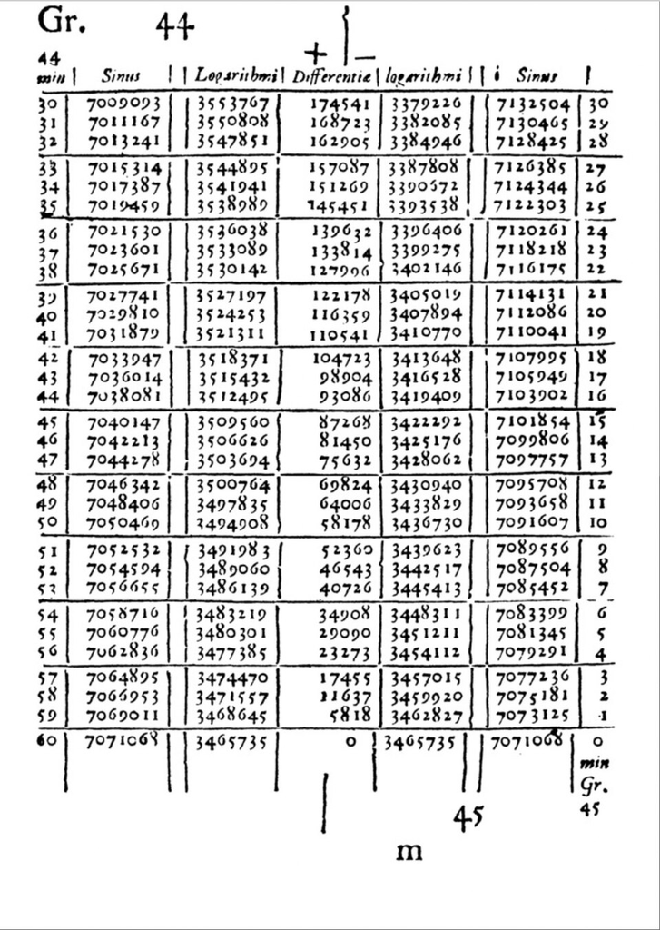

1614 tablice

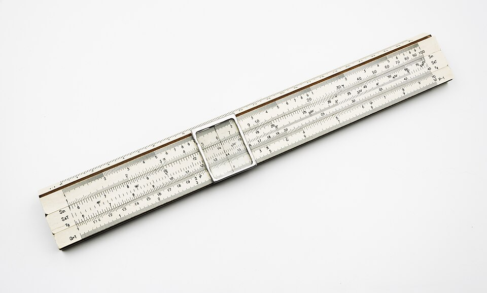

ok. 1620 suwak

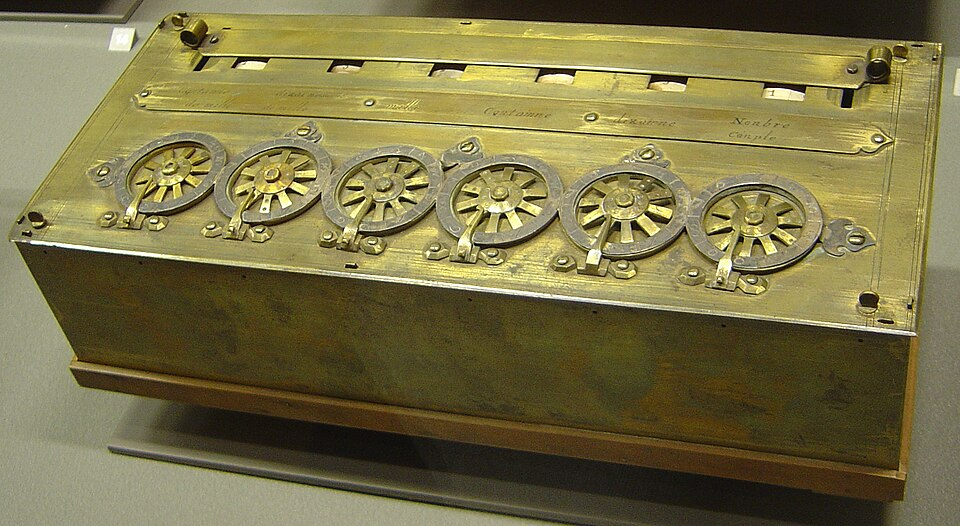

1642 maszyna

[figure not shown]

ok. 1790 komputer zbudowany z ludzi

Wikimedia Commons: tablica Napiera — domena publiczna; suwak — Jacek Halicki, CC BY-SA 4.0; Pascalina — David Monniaux, CC BY-SA 3.0

## Tabela strzelnicza

### Bez oporu powietrza

$x = v t \cos\alpha \qquad y = v t \sin\alpha - \tfrac{1}{2} g t^2$

zasięg: $\;R = \dfrac{v^2 \sin 2\alpha}{g}$

### Z oporem powietrza

wzoru nie ma — liczy się krok po kroku:  
**położenie → prędkość → nowe położenie**

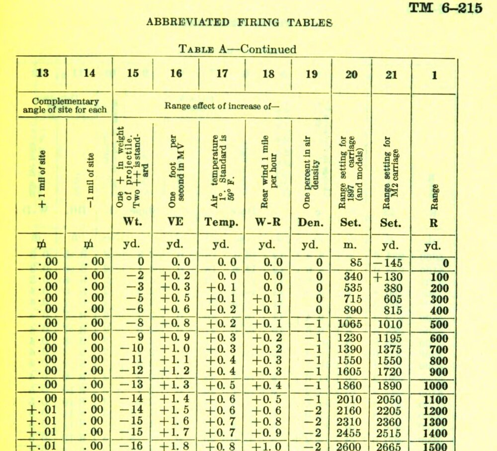

US Army, *Abbreviated Firing Tables* (TM 6-215), 1941

## Ludzie w roli maszyny

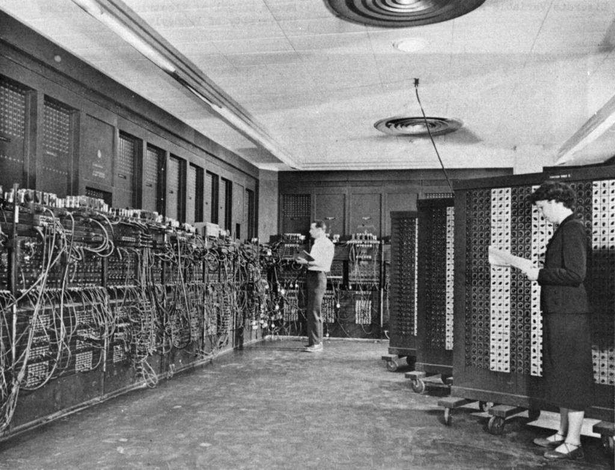

ENIAC: Glen Beck i Betty Snyder, ok. 1947–55 (U.S. Army)

jeden tor pocisku, który leci 60 sekund

człowiek z kalkulatorem biurkowym 20 godzin

analizator różniczkowy 15 minut

ENIAC 30 sekund

krócej niż czas lotu pocisku

# Sprawdzanie przypadków

rachunek sprawdzanie przypadków szukanie dowód pytania · teoria · zastosowania

## Cztery barwy

Czy każdą mapę da się pokolorować **czterema** kolorami tak, by sąsiednie kraje się różniły?

- 1852: pytanie stawia Francis Guthrie
- 1879: dowód Kempego
- 1890: Percy Heawood znajduje w nim błąd

[figure not shown]

## Dowód, którego nie da się przeczytać

[figure not shown]

## Cztery lata w pętli

[figure not shown]

# Dwie drogi programowania

## Algorytmiczny i trenowany

[figure not shown]

## Dwie drogi i matematyka

[figure not shown]

# Szukanie

rachunek sprawdzanie przypadków szukanie dowód pytania · teoria · zastosowania

## Ile mnożeń naprawdę trzeba?

$$\begin{pmatrix} a & b \\ c & d \end{pmatrix}
\begin{pmatrix} e & f \\ g & h \end{pmatrix}
=
\begin{pmatrix} ae + bg & af + bh \\ ce + dg & cf + dh \end{pmatrix}$$

Ten wzór wymaga **8 mnożeń**. Czy da się mniej?

$$\begin{aligned}
M_1 &= (a+d)(e+h)\\
M_2 &= (c+d)\,e\\
M_3 &= a\,(f-h)\\
M_4 &= d\,(g-e)\\
M_5 &= (a+b)\,h\\
M_6 &= (c-a)(e+f)\\
M_7 &= (b-d)(g+h)
\end{aligned}$$

$$\begin{aligned}
ae+bg &= M_1+M_4-M_5+M_7\\
af+bh &= M_3+M_5\\
ce+dg &= M_2+M_4\\
cf+dh &= M_1-M_2+M_3+M_6
\end{aligned}$$

Volker Strassen, 1969: **7 mnożeń**

## AlphaTensor (DeepMind, 2022)

[figure not shown]

## FunSearch (DeepMind, 2023)

Punkty o 8 współrzędnych, każda 0, 1 albo 2. Ile da się wybrać, by żadne trzy nie leżały na jednej prostej $\{p,\ p+v,\ p+2v\}$ ($p, v \in \mathbb{Z}_3^8$, $v \neq 0$)?

[figure not shown]

## Co napisał model?

[figure not shown]

# Dowód

rachunek sprawdzanie przypadków szukanie dowód pytania · teoria · zastosowania

## Olimpiada

[figure not shown]

## FrontierMath

[figure not shown]

## Problemy otwarte jako benchmark

[figure not shown]

## Hipoteza jakobianowa

Każde lokalnie odwracalne odwzorowanie wielomianowe $\mathbb{C}^n \to \mathbb{C}^n$ jest odwracalne.

**20 lipca 2026: kontrprzykład w $\mathbb{C}^3$** Levent Alpöge · Claude Fable 5

```python
from sympy import symbols, Matrix, Rational as Q
x, y, z = symbols("x y z")
u = 1 + x*y
F = Matrix([u**3*z + y**2*u*(4 + 3*x*y),
            y + 3*x*u**2*z + 3*x*y**2*(4 + 3*x*y),
            2*x - 3*x**2*y - x**3*z])
print(F.jacobian([x, y, z]).det().expand())
for p in [(0, 0, Q(-1,4)), (1, Q(-3,2), Q(13,2)), (-1, Q(3,2), Q(13,2))]:
    print(p, "→", tuple(F.subs(dict(zip((x, y, z), p)))))
```

```
-2
(0, 0, -1/4) → (-1/4, 0, 0)
(1, -3/2, 13/2) → (-1/4, 0, 0)
(-1, 3/2, 13/2) → (-1/4, 0, 0)
```

## Navier–Stokes

Clay 2000, **milion dolarów**: czy gładki przepływ w $\mathbb{R}^3$ może w skończonym czasie osiągnąć nieskończoną prędkość?

8 września 2026

OpenAI: **tak**, przy dobranej  
gładkiej sile zewnętrznej

ok. 10 000 agentów AI, 88 godzin  
166 stron dowodu + Lean

Stan na 18 października

Clay: problem „aktywny”, czeka na recenzję

Wersja w Lean nie pokrywa się z pracą (Cambridge, 6 X)

Sama praca: ani obalona, ani potwierdzona

## Matematyka hurtem

6 października 2026

OpenAI udostępnia naraz:

722 prace, 372 rodziny wyników  
z ok. 4000 problemów  
ok. 42% głównych wyników w Lean

Przykład: problem kasowania Zariskiego

Jeśli $X \times \mathbb{C} \cong \mathbb{C}^5$, to czy $X \cong \mathbb{C}^4$?

Czy po „skreśleniu” jednej osi zostaje przestrzeń?

**Nie:** jawny kontrprzykład (IX 2026)

$X = \{\, q^2u - (1+2yq)\,v - x^2v^2 - xz = 0 \,\} \subset \mathbb{C}^5$

gdzie $q = y^2 + z^3 + x^2u$

główne twierdzenie sprawdzone w Lean · praca bez recenzji

[github.com/openai/math](https://github.com/openai/math/tree/main/preprints/An-explicit-failure-of-complex-affine-space-cancellation-September-23-2026) → preprints → An explicit failure of complex affine-space cancellation

## Coraz gęściej

[figure not shown]

# Co zostało przy człowieku?

## Kto udowodnił to twierdzenie?

[figure not shown]

slajdy, źródła i wyniki demo

Dziękuję!

HAL 9000 (rysunek): Cryteria, Wikimedia Commons, CC BY 3.0